# Predicting Loan Default using Lending Club Dataset

**Part 1: Data Preparation, Exploration and Cleaning**

Load library and dataset

```r
pacman::p_load(dplyr, tidyverse, ggplot2, lubridate, reshape2, stringr, car, caret, ggpubr, dlookr, inspectdf)
setwd("C:/Users/Alvin/Documents/R Work Directory")
loans_all = read.csv("loans.csv", as.is = TRUE)
```

**Data exploration**

Check if all rows are filled  
Show percentage missing entries for each variable  
Remove data with missing values since instances of NA is not significant (<5%)

```r
summary(loans_all)
```

```
##       id             creditpolicy       loanamnt         term
##  Length:42514       Min.   :0.0000   Min.   :  500   Length:42514
##  Class :character   1st Qu.:1.0000   1st Qu.: 5200   Class :character
##  Mode  :character   Median :1.0000   Median : 9712   Mode  :character
##                     Mean   :0.9358   Mean   :11093
##                     3rd Qu.:1.0000   3rd Qu.:15000
##                     Max.   :1.0000   Max.   :35000
##
##     intrate        installment         grade            emplength
##  Min.   :0.0542   Min.   :  15.67   Length:42514       Length:42514
##  1st Qu.:0.0963   1st Qu.: 165.63   Class :character   Class :character
##  Median :0.1199   Median : 277.86   Mode  :character   Mode  :character
##  Mean   :0.1217   Mean   : 322.73
##  3rd Qu.:0.1472   3rd Qu.: 428.50
##  Max.   :0.2459   Max.   :1305.19
##
##  homeownership        annualinc       verificationstatus targetloanstatus
##  Length:42514       Min.   :   1896   Length:42514       Min.   :0.0000
##  Class :character   1st Qu.:  40000   Class :character   1st Qu.:0.0000
##  Mode  :character   Median :  59000   Mode  :character   Median :0.0000
##                     Mean   :  69140                      Mean   :0.1512
##                     3rd Qu.:  82500                      3rd Qu.:0.0000
##                     Max.   :6000000                      Max.   :1.0000
##                     NA's   :3
##    purpose               dti          delinq2yrs       inqlast6mths
##  Length:42514       Min.   : 0.00   Min.   : 0.0000   Min.   : 0.000
##  Class :character   1st Qu.: 8.20   1st Qu.: 0.0000   1st Qu.: 0.000
##  Mode  :character   Median :13.48   Median : 0.0000   Median : 1.000
##                     Mean   :13.38   Mean   : 0.1524   Mean   : 1.081
##                     3rd Qu.:18.68   3rd Qu.: 0.0000   3rd Qu.: 2.000
##                     Max.   :29.99   Max.   :13.0000   Max.   :33.000
##                                     NA's   :8         NA's   :8
##     openacc          revolbal         revolutil         totalacc
##  Min.   : 1.000   Min.   :      0   Min.   :0.0000   Min.   : 1.00
##  1st Qu.: 6.000   1st Qu.:   3642   1st Qu.:0.2570   1st Qu.:13.00
##  Median : 9.000   Median :   8828   Median :0.4970   Median :20.00
##  Mean   : 9.344   Mean   :  14305   Mean   :0.4912   Mean   :22.12
##  3rd Qu.:12.000   3rd Qu.:  17256   3rd Qu.:0.7270   3rd Qu.:29.00
##  Max.   :47.000   Max.   :1207359   Max.   :1.1900   Max.   :90.00
##  NA's   :8                          NA's   :69       NA's   :8
```

```r
colMeans(is.na(loans_all))*100
```

```
##                 id       creditpolicy           loanamnt
##        0.000000000        0.000000000        0.000000000
##               term            intrate        installment
##        0.000000000        0.000000000        0.000000000
##              grade          emplength      homeownership
##        0.000000000        0.000000000        0.000000000
##          annualinc verificationstatus   targetloanstatus
##        0.007056499        0.000000000        0.000000000
##            purpose                dti         delinq2yrs
##        0.000000000        0.000000000        0.018817331
##       inqlast6mths            openacc           revolbal
##        0.018817331        0.018817331        0.000000000
##          revolutil           totalacc
##        0.162299478        0.018817331
```

```r
loans = loans_all[complete.cases(loans_all),]
glimpse(loans)
```

```
## Observations: 42,445
## Variables: 20
## $ id                 <chr> "Arbt001", "Arbt002", "Arbt003", "Arbt004",...
## $ creditpolicy       <int> 1, 1, 1, 1, 1, 1, 1, 1, 1, 1, 1, 1, 1, 1, 1...
## $ loanamnt           <int> 5000, 2500, 2400, 10000, 3000, 5000, 7000, ...
## $ term               <chr> " 36 months", " 60 months", " 36 months", "...
## $ intrate            <dbl> 0.1065, 0.1527, 0.1596, 0.1349, 0.1269, 0.0...
## $ installment        <dbl> 162.87, 59.83, 84.33, 339.31, 67.79, 156.46...
## $ grade              <chr> "B", "C", "C", "C", "B", "A", "C", "E", "F"...
## $ emplength          <chr> "10+ years", "< 1 year", "10+ years", "10+ ...
## $ homeownership      <chr> "RENT", "RENT", "RENT", "RENT", "RENT", "RE...
## $ annualinc          <dbl> 24000.00, 30000.00, 12252.00, 49200.00, 800...
## $ verificationstatus <chr> "Verified", "Source Verified", "Not Verifie...
## $ targetloanstatus   <int> 0, 1, 0, 0, 0, 0, 0, 0, 1, 1, 0, 0, 1, 0, 1...
## $ purpose            <chr> "credit_card", "car", "small_business", "ot...
## $ dti                <dbl> 27.65, 1.00, 8.72, 20.00, 17.94, 11.20, 23....
## $ delinq2yrs         <int> 0, 0, 0, 0, 0, 0, 0, 0, 0, 0, 0, 0, 0, 0, 0...
## $ inqlast6mths       <int> 1, 5, 2, 1, 0, 3, 1, 2, 2, 0, 2, 0, 1, 2, 2...
## $ openacc            <int> 3, 3, 2, 10, 15, 9, 7, 4, 11, 2, 14, 12, 4,...
## $ revolbal           <int> 13648, 1687, 2956, 5598, 27783, 7963, 17726...
## $ revolutil          <dbl> 0.837, 0.094, 0.985, 0.210, 0.539, 0.283, 0...
## $ totalacc           <int> 9, 4, 10, 37, 38, 12, 11, 4, 13, 3, 23, 34,...
```

```r
summary(loans)
```

```
##       id             creditpolicy       loanamnt         term
##  Length:42445       Min.   :0.0000   Min.   :  500   Length:42445
##  Class :character   1st Qu.:1.0000   1st Qu.: 5200   Class :character
##  Mode  :character   Median :1.0000   Median : 9800   Mode  :character
##                     Mean   :0.9362   Mean   :11103
##                     3rd Qu.:1.0000   3rd Qu.:15000
##                     Max.   :1.0000   Max.   :35000
##     intrate        installment         grade            emplength
##  Min.   :0.0542   Min.   :  15.67   Length:42445       Length:42445
##  1st Qu.:0.0963   1st Qu.: 165.74   Class :character   Class :character
##  Median :0.1199   Median : 278.15   Mode  :character   Mode  :character
##  Mean   :0.1216   Mean   : 322.98
##  3rd Qu.:0.1472   3rd Qu.: 428.64
##  Max.   :0.2459   Max.   :1305.19
##  homeownership        annualinc       verificationstatus targetloanstatus
##  Length:42445       Min.   :   1896   Length:42445       Min.   :0.000
##  Class :character   1st Qu.:  40000   Class :character   1st Qu.:0.000
##  Mode  :character   Median :  59000   Mode  :character   Median :0.000
##                     Mean   :  69169                      Mean   :0.151
##                     3rd Qu.:  82500                      3rd Qu.:0.000
##                     Max.   :6000000                      Max.   :1.000
##    purpose               dti          delinq2yrs       inqlast6mths
##  Length:42445       Min.   : 0.00   Min.   : 0.0000   Min.   : 0.000
##  Class :character   1st Qu.: 8.21   1st Qu.: 0.0000   1st Qu.: 0.000
##  Mode  :character   Median :13.48   Median : 0.0000   Median : 1.000
##                     Mean   :13.38   Mean   : 0.1525   Mean   : 1.081
##                     3rd Qu.:18.69   3rd Qu.: 0.0000   3rd Qu.: 2.000
##                     Max.   :29.99   Max.   :13.0000   Max.   :33.000
##     openacc          revolbal         revolutil         totalacc
##  Min.   : 1.000   Min.   :      0   Min.   :0.0000   Min.   : 1.00
##  1st Qu.: 6.000   1st Qu.:   3665   1st Qu.:0.2570   1st Qu.:13.00
##  Median : 9.000   Median :   8847   Median :0.4970   Median :20.00
##  Mean   : 9.351   Mean   :  14320   Mean   :0.4912   Mean   :22.14
##  3rd Qu.:12.000   3rd Qu.:  17268   3rd Qu.:0.7270   3rd Qu.:29.00
##  Max.   :47.000   Max.   :1207359   Max.   :1.1900   Max.   :90.00
```

```r
nrow(loans)/nrow(loans_all)
```

```
## [1] 0.998377
```

99.8% of original entries are retained

Change dependent variable “target loan status” to factor

```r
loans$targetloanstatus <- as.factor(loans$targetloanstatus)
```

Exploratory Data Analysis

Show current loan default status  
“Target loan status” = 1 means defaulted on loan

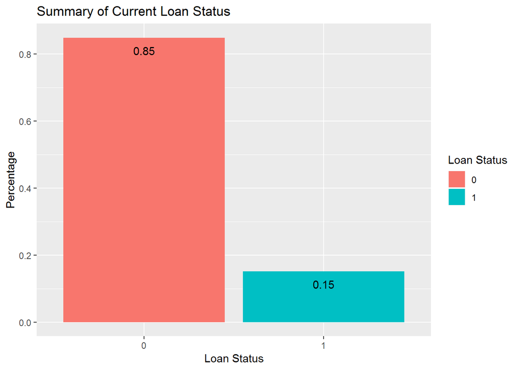

```r
loans %>%
  group_by(targetloanstatus)%>%
  summarise(per = n()/nrow(loans))%>%
  ggplot(aes(x=targetloanstatus, y=per, fill = targetloanstatus)) +
  geom_bar(stat='identity') +
  geom_text(aes(label = round(per, 2)), vjust = 2) + labs(fill = "Loan Status", title = "Summary of Current Loan Status", x = "Loan Status", y = "Percentage")
```

15% of borrowers defaulted on loan

Plot percentage defaulted by grade

```r
p1 = loans %>%
  group_by(grade) %>%
  count(targetloanstatus) %>%
  mutate(percentage = n/sum(n)) %>%
  ggplot(aes(x = grade, y = percentage)) +
  geom_col(aes(fill = targetloanstatus)) +
  labs(title = "percentage of defaulters") + ylab("default %")
```

Plot loan status by term of loan

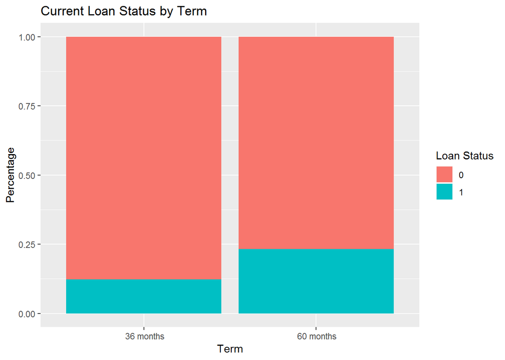

```r
loans %>%
  group_by(term, targetloanstatus) %>%
  summarise(count_level = n(), percentage = n()/nrow(loans)) %>%
  ggplot(aes(x = term, y = percentage, fill = targetloanstatus)) +
  geom_bar(position = 'fill', stat = 'identity') +
  labs(title="Current Loan Status by Term", x = "Term", y = "Percentage", fill = "Loan Status")
```

Higher chance of default for long term (60 months) loan

Plot loan status by grade and loan amount

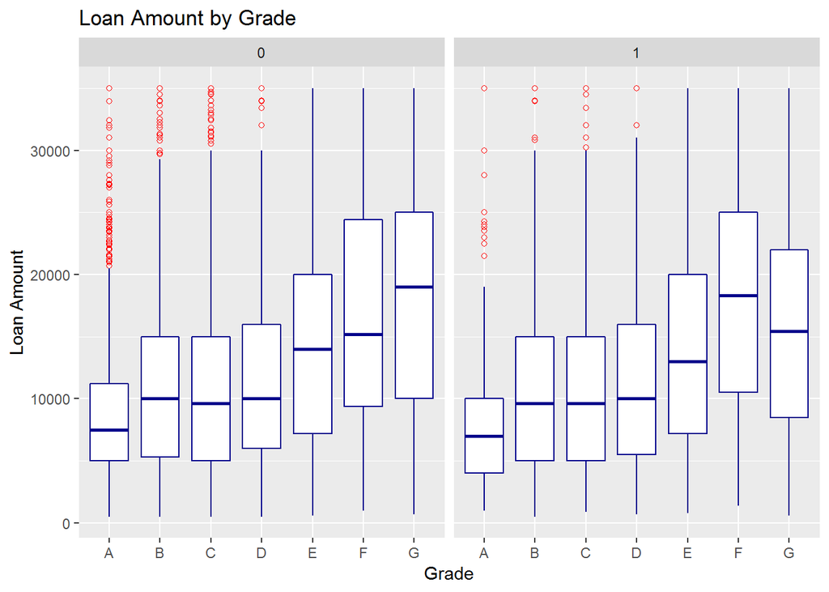

```r
loans %>%
  ggplot(aes(grade, loanamnt)) +
  geom_boxplot(fill = "white", colour = "darkblue",
               outlier.colour = "red", outlier.shape = 1) +
  scale_y_continuous() +
  facet_wrap(~ targetloanstatus) +
  labs(title="Loan Amount by Grade", x = "Grade", y = "Loan Amount")
```

Typically higher loan amount at lower grade  
Outliers are common for grades A - D  
The loan amount spread (IQR) is higher for lower grade loans

Plot loan status against grade

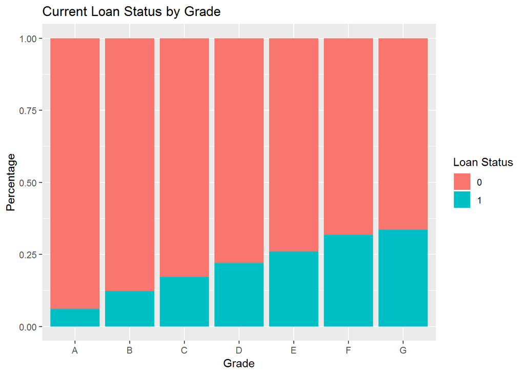

```r
loans %>%
  group_by(grade, targetloanstatus) %>%
  summarise(count_level = n(), percentage = n()/nrow(loans)) %>%
  ggplot(aes(x = grade, y = percentage, fill = targetloanstatus)) +
  geom_bar(position = 'fill', stat = 'identity') +
  labs(title="Current Loan Status by Grade", x = "Grade", y = "Percentage", fill = "Loan Status")
```

Plot revolving balance and target loan status

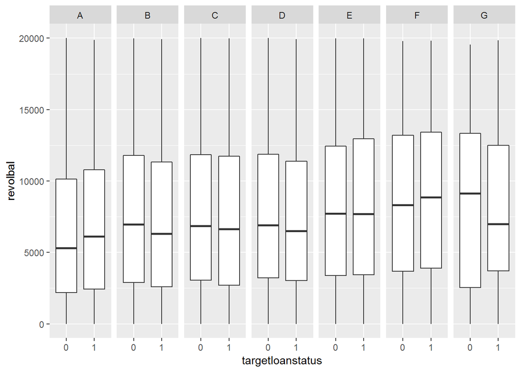

```r
loans %>%
  ggplot(aes(x = targetloanstatus)) +
  geom_boxplot(aes(y=revolbal), outlier.shape = NA) + facet_grid(~grade) +
  scale_y_continuous(limits = c(0,20000))
```

Non-visual summaries

```r
loans %>%
  group_by(targetloanstatus) %>%
  summarise(ratio = n()/nrow(loans), count = n())
```

```
## # A tibble: 2 x 3
##   targetloanstatus ratio count
##   <fct>            <dbl> <int>
## 1 0                0.849 36036
## 2 1                0.151  6409
```

```r
loans %>%
  group_by(targetloanstatus) %>%
  count(creditpolicy) %>%
  mutate(perc = n/sum(n))
```

```
## # A tibble: 4 x 4
## # Groups:   targetloanstatus [2]
##   targetloanstatus creditpolicy     n   perc
##   <fct>                   <int> <int>  <dbl>
## 1 0                           0  1954 0.0542
## 2 0                           1 34082 0.946
## 3 1                           0   755 0.118
## 4 1                           1  5654 0.882
```

**Data cleaning**

Clean emplength and term lines

```r
table(loans$term, useNA = "always")
```

```
##
##  36 months  60 months       <NA>
##      31448      10997          0
```

```r
loans$term %>%
  str_extract("\\d{1,2}") -> loans$term

table(loans$emplength, useNA = "always")
```

```
##
##  < 1 year    1 year 10+ years   2 years   3 years   4 years   5 years
##      5029      3584      9365      4736      4358      3640      3453
##   6 years   7 years   8 years   9 years       n/a      <NA>
##      2371      1872      1589      1339      1109         0
```

```r
loans$emplength %>%
  str_replace("< 1", "1") %>%
  str_replace("n/a", "0") %>%
  str_extract("\\d{1,2}") -> loans$emplength
loans[,c("term","emplength")] =
  lapply(loans[,c("term","emplength")], as.integer)
table(loans$emplength, useNA = "always")
```

```
##
##    0    1    2    3    4    5    6    7    8    9   10 <NA>
## 1109 8613 4736 4358 3640 3453 2371 1872 1589 1339 9365    0
```

Convert grade to numeric class

```r
loans = loans %>%
  mutate(recodegrade = (case_when(grade == "A" ~ 1,
                                  grade == "B" ~ 2,
                                  grade == "C" ~ 3,
                                  grade == "D" ~ 4,
                                  grade == "E" ~ 5,
                                  grade == "F" ~ 6,
                                  grade == "G" ~ 7)))
```

```r
loans = loans %>%
  mutate(delin2years = factor(case_when(delinq2yrs > 0 ~ "Y",
                                        delinq2yrs == 0 ~ "N")),
         homeowner = factor(ifelse(homeownership == "MORTGAGE"|homeownership == "OWN",
                                   "Y", "N")))

table(loans$delin2years, loans$delinq2yrs)
```

```
##
##         0     1     2     3     4     5     6     7     8     9    11
##   N 37714     0     0     0     0     0     0     0     0     0     0
##   Y     0  3593   770   244    71    27    13     6     3     1     2
##
##        13
##   N     0
##   Y     1
```

```r
table(loans$homeowner, loans$homeownership)
```

```
##
##     MORTGAGE  NONE OTHER   OWN  RENT
##   N        0     4   134     0 20126
##   Y    18938     0     0  3243     0
```

Apply log transformation to annualinc and revolbal

```r
loans = loans %>%
  mutate(logannualinc = log(1+annualinc),
         logrevolbal = log(1+revolbal))
```

Create ratio for openacc/totalacc

```r
loans = loans %>%
  mutate(ratioacc = openacc/totalacc)
```

Recode (1) verification status and (2) purpose into 7 main categories  
Create new variable purpose_mod

```r
table(loans$verificationstatus, useNA = "always")
```

```
##
##    Not Verified Source Verified        Verified            <NA>
##           18691           10294           13460               0
```

```r
loans$verified = factor(ifelse(loans$verificationstatus == "Not Verified", "N","Y"))
table(loans$verified, loans$verificationstatus)
```

```
##
##     Not Verified Source Verified Verified
##   N        18691               0        0
##   Y            0           10294    13460
```

```r
loans = loans%>%
  mutate(purpose_mod = recode_factor(purpose,"home_improvement" = "living_expenses",
                                     "educational" = "living_expenses", "home_improvement" = "living_expenses", "house" = "living_expenses"
                                     , "major_purchase" = "luxury", "medical" = "living_expenses", "moving" = "living_expenses",
                                     "renewable_energy" = "business", "small_business" = "business", "vacation" = "luxury", "wedding" = "living_expenses"))

unique(loans$purpose_mod)
```

```
## [1] credit_card        car                business
## [4] other              living_expenses    debt_consolidation
## [7] luxury
## 7 Levels: living_expenses luxury business credit_card car ... debt_consolidation
```

```r
str(loans$purpose_mod)
```

```
##  Factor w/ 7 levels "living_expenses",..: 4 5 3 6 6 1 7 5 3 6 ...
```

Factorise catagorical variables

```r
loans[,c("creditpolicy", "grade", "homeownership", "verificationstatus","targetloanstatus","purpose")] =
  lapply(loans[,c("creditpolicy", "grade", "homeownership", "verificationstatus","targetloanstatus","purpose")], as.factor)
```

Plot purpose by loan status for modified purpose category

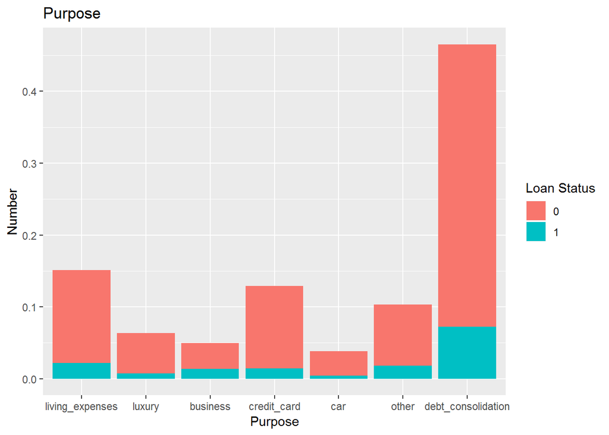

```r
loans %>%
  group_by(purpose_mod, targetloanstatus) %>%
  summarise(count_level = n(), percentage = n()/nrow(loans)) %>%
  ggplot(aes(x = purpose_mod, y = percentage, fill = targetloanstatus)) +
  geom_bar(stat = 'identity') +
  labs(title="Purpose", x = "Purpose", y = "Number", fill = "Loan Status")
```

Create business variables for model evaluation in the end. Lending Club states a 5% upfront fee.

```r
loans = loans %>%
  mutate(potl_profit = intrate*loanamnt + 0.05*loanamnt,
         loss = case_when(targetloanstatus == 0 ~ 0,
                          targetloanstatus == 1 ~ as.double(loanamnt)*0.95),
         profit = case_when(loss == 0 ~ potl_profit,
                            loss != 0 ~ 0))

loans %>%
  group_by(grade, targetloanstatus) %>%
  summarize(sum = sum(potl_profit)) %>%
  ungroup() %>%
  mutate(perc = sum/sum(sum))
```

```
## # A tibble: 14 x 4
##    grade targetloanstatus       sum    perc
##    <fct> <fct>                <dbl>   <dbl>
##  1 A     0                10237567. 0.121
##  2 A     1                  597302. 0.00709
##  3 B     0                19362137. 0.230
##  4 B     1                 2646828. 0.0314
##  5 C     0                14567422. 0.173
##  6 C     1                 3049063. 0.0362
##  7 D     0                11558279. 0.137
##  8 D     1                 3216840. 0.0382
##  9 E     0                 8407941. 0.0997
## 10 E     1                 2922072. 0.0347
## 11 F     0                 3637512. 0.0431
## 12 F     1                 1846178. 0.0219
## 13 G     0                 1540679. 0.0183
## 14 G     1                  714965. 0.00848
```

Select Features for Modelling

```r
loans_df = select(loans, -c("id","homeownership","annualinc","revolbal","verificationstatus","delinq2yrs", "purpose", "profit", "loss", "potl_profit","openacc"))
glimpse(loans_df)
```

```
## Observations: 42,445
## Variables: 20
## $ creditpolicy     <fct> 1, 1, 1, 1, 1, 1, 1, 1, 1, 1, 1, 1, 1, 1, 1, ...
## $ loanamnt         <int> 5000, 2500, 2400, 10000, 3000, 5000, 7000, 30...
## $ term             <int> 36, 60, 36, 36, 60, 36, 60, 36, 60, 60, 60, 3...
## $ intrate          <dbl> 0.1065, 0.1527, 0.1596, 0.1349, 0.1269, 0.079...
## $ installment      <dbl> 162.87, 59.83, 84.33, 339.31, 67.79, 156.46, ...
## $ grade            <fct> B, C, C, C, B, A, C, E, F, B, C, B, C, B, B, ...
## $ emplength        <int> 10, 1, 10, 10, 1, 3, 8, 9, 4, 1, 5, 10, 1, 3,...
## $ targetloanstatus <fct> 0, 1, 0, 0, 0, 0, 0, 0, 1, 1, 0, 0, 1, 0, 1, ...
## $ dti              <dbl> 27.65, 1.00, 8.72, 20.00, 17.94, 11.20, 23.51...
## $ inqlast6mths     <int> 1, 5, 2, 1, 0, 3, 1, 2, 2, 0, 2, 0, 1, 2, 2, ...
## $ revolutil        <dbl> 0.837, 0.094, 0.985, 0.210, 0.539, 0.283, 0.8...
## $ totalacc         <int> 9, 4, 10, 37, 38, 12, 11, 4, 13, 3, 23, 34, 9...
## $ recodegrade      <dbl> 2, 3, 3, 3, 2, 1, 3, 5, 6, 2, 3, 2, 3, 2, 2, ...
## $ delin2years      <fct> N, N, N, N, N, N, N, N, N, N, N, N, N, N, N, ...
## $ homeowner        <fct> N, N, N, N, N, N, N, N, Y, N, Y, Y, N, N, N, ...
## $ logannualinc     <dbl> 10.085851, 10.308986, 9.413526, 10.803669, 11...
## $ logrevolbal      <dbl> 9.521422, 7.431300, 7.991931, 8.630343, 10.23...
## $ ratioacc         <dbl> 0.3333333, 0.7500000, 0.2000000, 0.2702703, 0...
## $ verified         <fct> Y, Y, N, Y, Y, Y, N, Y, Y, Y, N, Y, Y, Y, Y, ...
## $ purpose_mod      <fct> credit_card, car, business, other, other, liv...
```

```r
loans_test = select(loans, c("profit","loss","targetloanstatus"))
glimpse(loans_test)
```

```
## Observations: 42,445
## Variables: 3
## $ profit           <dbl> 782.500, 0.000, 503.040, 1849.000, 530.700, 6...
## $ loss             <dbl> 0.00, 2375.00, 0.00, 0.00, 0.00, 0.00, 0.00, ...
## $ targetloanstatus <fct> 0, 1, 0, 0, 0, 0, 0, 0, 1, 1, 0, 0, 1, 0, 1, ...
```

Plot correlation of Numerical Variables  
Visualise dataset for modelling

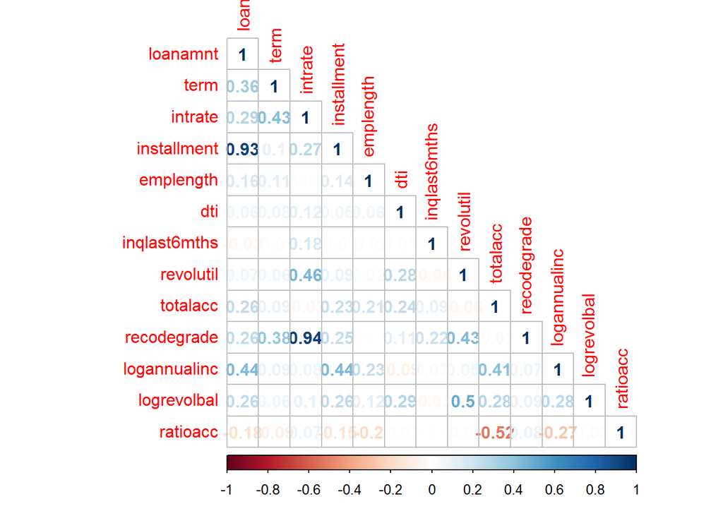

```r
corrplot::corrplot(cor(loans_df[, sapply(loans_df, is.numeric)],
                       use="complete.obs"), method = "number", type='lower')
```

```r
loans_df = select(loans_df, -c("installment","grade","recodegrade"))
```

Write to csv

```r
write.csv(loans_df, "loansformodelling.csv", row.names = F)
write.csv(loans_test, "loansfortest.csv", row.names = F)
```